# Exercicios_Capitulo_03

## ANÁLISE DE SOBREVIVÊNCIA

### Teoria e aplicações em saúde

#### Capítulo 3: Funções Básicas de sobrevivência

#### Exercícios Resolvidos

###### Autor: Carlos Ed Beluzo - cbeluzo@gmail.com

###### Maio de 2020

## Tópicos:

- Importação de bibliotecas e leitura do arquivo CSV
- Funções:
- Exercícios
  - Exercício 3.1
  - Exercício 3.2
  - Exercício 3.3
  - Exercício 3.4

```python
import sympy as sym
sym.init_printing(use_latex=False, use_unicode=False, wrap_line=True)
# Example sym.expand(1-x*x/2+x**4/24+y**(x**6))
```

##### Função de densidade de probabilidade (p. 78)

```python
print('Função de densidade de probabilidade (p. 78)')
print(' (Probabilidade de um indivííduo sofrer um evento em um intervalo instantâneo de tempo.)\n')

# Defining functions
f = sym.Function('f')
Pr = sym.Function('Pr')

# Defining variables
t = sym.Symbol('t')
T = sym.Symbol('T')
epsilon = sym.Symbol('\u03B5')

# Grather than symbols
gfg = sym.Le(t, sym.Lt(T, t + epsilon))

# Mount equation
myEq = sym.Eq(f(t), sym.Limit( Pr(gfg) / epsilon , epsilon, 0))
sym.pprint(myEq)

print('\nSendo,\n')
print('Pr = Probabilidade de ocorrencia do evento')
print('\u03B5 = Incremento de tempo infinitamente pequeno')
print('T = Tempo de sobrevivêcia')
```

```
Função de densidade de probabilidade (p. 78)
 (Probabilidade de um indivííduo sofrer um evento em um intervalo instantâneo de tempo.)

            /Pr(t <= T < t + ε)\
f(t) =  lim |------------------|
       ε->0+\        ε         /

Sendo,

Pr = Probabilidade de ocorrencia do evento
ε = Incremento de tempo infinitamente pequeno
T = Tempo de sobrevivêcia
```

##### Função de densidade do tempo de sobrevivência (p. 79)

```python
print('Função de densidade do tempo de sobrevivência (p. 79)\n')

# Define funcitons
fx_hat = sym.Function('f\u0302\u2093') # '209' means subscript, and '3' means x. See Unicode subscripts.
Nx = sym.Function('N\u2093')

# Define variables
delta = sym.Symbol('\u0394\u2093')
t = sym.Symbol('t')
totalOccur = sym.Symbol('(n\u00B0 total de ocorrências)')

# Mount  equations
myEq = sym.Eq(fx_hat(t), Nx(t)/(totalOccur * delta))
sym.pprint(myEq)
print('\nSendo,\n')
print('N\u2093 = número de ocorrências no intervalo de tempo x')
print('\u0394\u2093 = amplitude do intervalo de tempo x')
print('x = índice do intervalo')
```

```
Função de densidade do tempo de sobrevivência (p. 79)

                    Nₓ(t)
f̂ₓ(t) = ----------------------------
         (n° total de ocorrências)*Δₓ

Sendo,

Nₓ = número de ocorrências no intervalo de tempo x
Δₓ = amplitude do intervalo de tempo x
x = índice do intervalo
```

### Importação de bibliotecas e leitura do arquivco CSV

#### Download file CSV and images from GDrive location

```python
import gdown

output = 'DM017_AIDS.csv'
fileId='1Kd7gbkretoFsv0yADZueYQ6qHNOonM5i'
url = 'https://drive.google.com/uc?id=%s' % fileId
gdown.download(url, output, quiet=False)

myImg = 'exercicio-3_1.png'
fileId='15mu0oCf4c0sfQQUFL4fvkmkvdofW_JMQ'
url = 'https://drive.google.com/uc?id=%s' % fileId
gdown.download(url, myImg, quiet=False)

myImg = 'exercicio-3_1a.png'
fileId='18nxjBbb3SgQWjLXcwzUU83t9WYKtkS3I'
url = 'https://drive.google.com/uc?id=%s' % fileId
gdown.download(url, myImg, quiet=False)

myImg = 'exercicio-3_1b.png'
fileId='1nK1xThEFVUdhv_I5AjzmfW1AHmDvQM0D'
url = 'https://drive.google.com/uc?id=%s' % fileId
gdown.download(url, myImg, quiet=False)

myImg = 'exercicio-3_1c.png'
fileId='1HYP5fEBxtxxT_m4L4WW3CNz0rPE8NhCx'
url = 'https://drive.google.com/uc?id=%s' % fileId
gdown.download(url, myImg, quiet=False)
```

```
Downloading...
From: https://drive.google.com/uc?id=1Kd7gbkretoFsv0yADZueYQ6qHNOonM5i
To: /content/drive/My Drive/Colab Notebooks/DM017_ANALISE_DE_SOBREVIVENCIA/DM017_AIDS.csv
Downloading...
From: https://drive.google.com/uc?id=15mu0oCf4c0sfQQUFL4fvkmkvdofW_JMQ
To: /content/drive/My Drive/Colab Notebooks/DM017_ANALISE_DE_SOBREVIVENCIA/exercicio-3_1.png
Downloading...
From: https://drive.google.com/uc?id=18nxjBbb3SgQWjLXcwzUU83t9WYKtkS3I
To: /content/drive/My Drive/Colab Notebooks/DM017_ANALISE_DE_SOBREVIVENCIA/exercicio-3_1a.png
Downloading...
From: https://drive.google.com/uc?id=1nK1xThEFVUdhv_I5AjzmfW1AHmDvQM0D
To: /content/drive/My Drive/Colab Notebooks/DM017_ANALISE_DE_SOBREVIVENCIA/exercicio-3_1b.png
Downloading...
From: https://drive.google.com/uc?id=1HYP5fEBxtxxT_m4L4WW3CNz0rPE8NhCx
To: /content/drive/My Drive/Colab Notebooks/DM017_ANALISE_DE_SOBREVIVENCIA/exercicio-3_1c.png
```

```
'exercicio-3_1c.png'
```

#### Importação de bibliotecas

```python
import pandas as pd
import numpy as np
import matplotlib.pyplot as plt
import plotly as plt
import plotly.express as px
import plotly.graph_objects as go

plt.offline.init_notebook_mode()
```

## Exercício 3.1

A figura a seguir mostra uma curva de sobrevivência. Com base nesta curva indentifique:

- **a) A probabilidade de sobreviver por mais de 10 dias.**
- **b) A sobrevivência mediana e o tempo mediano de sobrevivência.**
- **c) O tempo em que 80% dos pacientes ainda estavam vivos.**

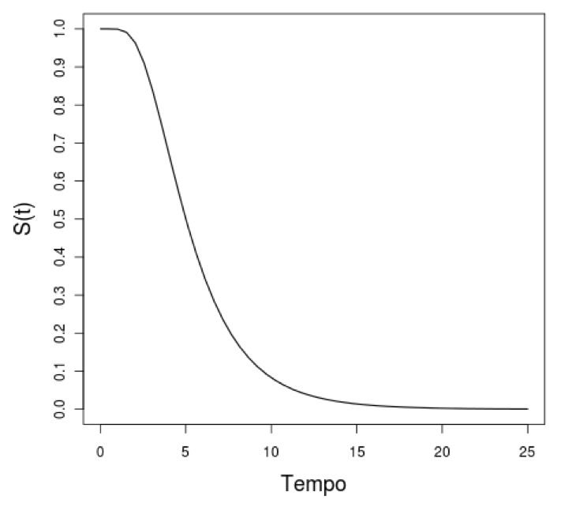

```python
from IPython.core.display import Image
Image(filename = "exercicio-3_1.png", width=400, height=400)
```

#### a) A probabilidade de sobreviver por mais de 10 dias.

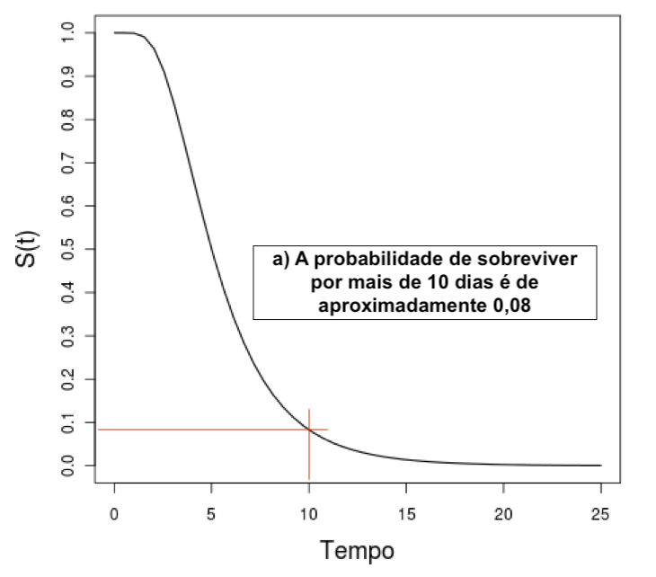

```python
Image(filename = "exercicio-3_1a.png", width=400, height=400)
```

#### b) A *sobrevivência* mediana e o tempo mediano de sobrevivência.

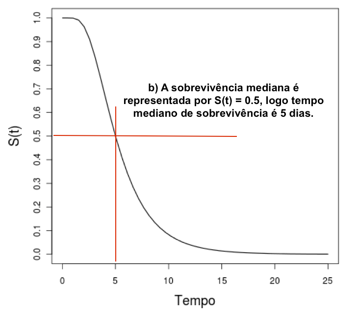

```python
Image(filename = "exercicio-3_1b.png", width=400, height=400)
```

#### c) O tempo em que 80% dos pacientes ainda estavam vivos.

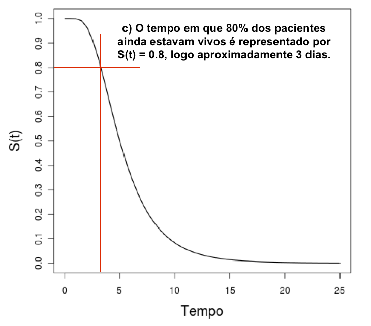

```python
Image(filename = "exercicio-3_1c.png", width=400, height=400)
```

## Exercício 3.2: Sabendo-se que a probabilidade de sobreviver mais que 100 dias após o transplante de coração é igual a 0,7, calcule:

- **a) A probabilidade de sobreviver por, no máximo, 100 dias (inclusive);**
- **b) O risco acumulado do óbito ocorrer em até 100 dias (ou seja, no máximo em 100 dias);**
- **c) O risco acumulado do óbito ocorrer após 100 dias (ou seja, no mínimo em 100 dias).**

#### a) A probabilidade de sobreviver por, no máximo, 100 dias (inclusive);

[output not shown]

#### b) O risco acumulado do óbito ocorrer em até 100 dias (ou seja, no máximo em 100 dias);

```
Ʌ(t) = −ln(S(t))
Ʌ(t) = −ln(0.7)
Ʌ(t) = 0.357

Onde,
Ʌ(t) = Risco Acumulado do óbito até o tempo t
```

```python
import numpy as np
-np.log(0.7)
```

```
0.35667494393873245
```

#### c) O risco acumulado do óbito ocorrer após 100 dias (ou seja, no mínimo em 100 dias).

```
Ʌ(t) = −ln(S(t))
Ʌ(t) = −ln(0.3)
Ʌ(t) = 1.204

Onde,
Ʌ(t) = Risco Acumulado do óbito até o tempo t
```

```python
import numpy as np
-np.log(0.3)
```

```
1.2039728043259361
```

## Exercício 3.3: A tabela a seguir mostra o tempo até o óbito de alguns pacientes de uma coorte de 32 indivíduos vivendo com AIDS, não havendo tempos censurados. Complete as lacunas em branco usando as definições e as relações entre as funções básicas de sobrevivência, onde T é o tempo até o óbito, R(t) é o número de pessoas sob risco no início do intervalo de tempo, N(t) é o número de óbitos ocorridos no intervalo de tempo.

```python
df = pd.read_csv(output, sep=';')

df.fillna(0,inplace=True)
df[['Evento acumulado']] = df.astype({'Evento acumulado': 'int64'}).dtypes
df[['Amplitude do intervalo']] = df.astype({'Amplitude do intervalo': 'int64'}).dtypes
df.fillna(0,inplace=True)

df.loc[0,'Intervalo'] = '0:0'

for i in range(1,df.shape[0]-1):
  df.loc[i,'Evento acumulado'] = df.loc[i,'Eventos'] + df.loc[i-1,'Evento acumulado']
  df.loc[i,'Intervalo'] = str('%s:%s' % (str(df.loc[(i),'Tempo']), str(df.loc[(i+1),'Tempo'])))
  df.loc[i,'Amplitude do intervalo'] = df.loc[i+1,'Tempo'] - df.loc[(i),'Tempo']
  df.loc[i,'Função de densidade'] = df.loc[i,'Eventos'] / (df.loc[0,'Risco'] * df.loc[i,'Amplitude do intervalo'])
  df.loc[i,'Densidade acumulada'] = df.loc[i-1, 'Densidade acumulada'] + (df.loc[i-1, 'Amplitude do intervalo'] * df.loc[i-1,'Função de densidade'])
  df.loc[i,'Sobrevida'] = 1 - df.loc[i,'Densidade acumulada']
  df.loc[i,'Função de Risco'] = df.loc[i,'Função de densidade'] / df.loc[i,'Sobrevida']
  df.loc[i,'Função de Risco Acumulado'] = -np.log(df.loc[i,'Sobrevida'])

colNames = {'Tempo':'t',
            'Risco':'R(t)',
            'Eventos':'N(t)',
            'Evento acumulado':'\u03A3 N(t)',
            'Intervalo':'x',
            'Amplitude do intervalo':'\u0394\u2093(t)',
            'Função de densidade':'f\u0302\u2093(t)',
            'Densidade acumulada':'F\u2093(t)',
            'Sobrevida':'S\u2093(t)',
            'Função de Risco':'\u03BB\u2093(t)',
            'Função de Risco Acumulado':'\u039B\u2093(t)'
}

df.rename(columns=colNames, inplace=True)
df
```

|  | t | R(t) | N(t) | Σ N(t) | x | Δₓ(t) | f̂ₓ(t) | Fₓ(t) | Sₓ(t) | λₓ(t) | Λₓ(t) |
| --- | --- | --- | --- | --- | --- | --- | --- | --- | --- | --- | --- |
| 0 | 0 | 32.0 | 0.0 | 0.0 | 0:0 | 0 | 0.000000 | 0.00000 | 0.00000 | 0.000000 | 0.000000 |
| 1 | 0 | 32.0 | 1.0 | 1.0 | 0:3 | 3 | 0.010417 | 0.00000 | 1.00000 | 0.010417 | -0.000000 |
| 2 | 3 | 31.0 | 1.0 | 2.0 | 3:18 | 15 | 0.002083 | 0.03125 | 0.96875 | 0.002151 | 0.031749 |
| 3 | 18 | 30.0 | 1.0 | 3.0 | 18:29 | 11 | 0.002841 | 0.06250 | 0.93750 | 0.003030 | 0.064539 |
| 4 | 29 | 29.0 | 1.0 | 4.0 | 29:54 | 25 | 0.001250 | 0.09375 | 0.90625 | 0.001379 | 0.098440 |
| 5 | 54 | 28.0 | 1.0 | 5.0 | 54:60 | 6 | 0.005208 | 0.12500 | 0.87500 | 0.005952 | 0.133531 |
| 6 | 60 | 27.0 | 1.0 | 6.0 | 60:84 | 24 | 0.001302 | 0.15625 | 0.84375 | 0.001543 | 0.169899 |
| 7 | 84 | 26.0 | 1.0 | 7.0 | 84:110 | 26 | 0.001202 | 0.18750 | 0.81250 | 0.001479 | 0.207639 |
| 8 | 110 | 25.0 | 1.0 | 8.0 | 110:112 | 2 | 0.015625 | 0.21875 | 0.78125 | 0.020000 | 0.246860 |
| 9 | 112 | 24.0 | 1.0 | 9.0 | 112:116 | 4 | 0.007812 | 0.25000 | 0.75000 | 0.010417 | 0.287682 |
| 10 | 116 | 23.0 | 1.0 | 10.0 | 116:123 | 7 | 0.004464 | 0.28125 | 0.71875 | 0.006211 | 0.330242 |
| 11 | 123 | 22.0 | 1.0 | 11.0 | 123:134 | 11 | 0.002841 | 0.31250 | 0.68750 | 0.004132 | 0.374693 |
| 12 | 134 | 21.0 | 1.0 | 12.0 | 134:145 | 11 | 0.002841 | 0.34375 | 0.65625 | 0.004329 | 0.421213 |
| 13 | 145 | 20.0 | 2.0 | 14.0 | 145:151 | 6 | 0.010417 | 0.37500 | 0.62500 | 0.016667 | 0.470004 |
| 14 | 151 | 18.0 | 1.0 | 15.0 | 151:158 | 7 | 0.004464 | 0.43750 | 0.56250 | 0.007937 | 0.575364 |
| 15 | 158 | 17.0 | 1.0 | 16.0 | 158:173 | 15 | 0.002083 | 0.46875 | 0.53125 | 0.003922 | 0.632523 |
| 16 | 173 | 16.0 | 1.0 | 17.0 | 173:194 | 21 | 0.001488 | 0.50000 | 0.50000 | 0.002976 | 0.693147 |
| 17 | 194 | 15.0 | 1.0 | 18.0 | 194:214 | 20 | 0.001563 | 0.53125 | 0.46875 | 0.003333 | 0.757686 |
| 18 | 214 | 14.0 | 1.0 | 19.0 | 214:329 | 115 | 0.000272 | 0.56250 | 0.43750 | 0.000621 | 0.826679 |
| 19 | 329 | 13.0 | 1.0 | 20.0 | 329:331 | 2 | 0.015625 | 0.59375 | 0.40625 | 0.038462 | 0.900787 |
| 20 | 331 | 12.0 | 1.0 | 21.0 | 331:371 | 40 | 0.000781 | 0.62500 | 0.37500 | 0.002083 | 0.980829 |
| 21 | 371 | 11.0 | 1.0 | 22.0 | 371:408 | 37 | 0.000845 | 0.65625 | 0.34375 | 0.002457 | 1.067841 |
| 22 | 408 | 10.0 | 1.0 | 23.0 | 408:490 | 82 | 0.000381 | 0.68750 | 0.31250 | 0.001220 | 1.163151 |
| 23 | 490 | 9.0 | 1.0 | 24.0 | 490:514 | 24 | 0.001302 | 0.71875 | 0.28125 | 0.004630 | 1.268511 |
| 24 | 514 | 8.0 | 1.0 | 25.0 | 514:541 | 27 | 0.001157 | 0.75000 | 0.25000 | 0.004630 | 1.386294 |
| 25 | 541 | 7.0 | 1.0 | 26.0 | 541:555 | 14 | 0.002232 | 0.78125 | 0.21875 | 0.010204 | 1.519826 |
| 26 | 555 | 6.0 | 1.0 | 27.0 | 555:688 | 133 | 0.000235 | 0.81250 | 0.18750 | 0.001253 | 1.673976 |
| 27 | 688 | 5.0 | 1.0 | 28.0 | 688:780 | 92 | 0.000340 | 0.84375 | 0.15625 | 0.002174 | 1.856298 |
| 28 | 780 | 4.0 | 1.0 | 29.0 | 780:801 | 21 | 0.001488 | 0.87500 | 0.12500 | 0.011905 | 2.079442 |
| 29 | 801 | 3.0 | 1.0 | 30.0 | 801:858 | 57 | 0.000548 | 0.90625 | 0.09375 | 0.005848 | 2.367124 |
| 30 | 858 | 2.0 | 1.0 | 31.0 | 858:887 | 29 | 0.001078 | 0.93750 | 0.06250 | 0.017241 | 2.772589 |
| 31 | 887 | 1.0 | 1.0 | 32.0 | 887:998 | 111 | 0.000282 | 0.96875 | 0.03125 | 0.009009 | 3.465736 |
| 32 | 998 | 0.0 | 0.0 | 0.0 | 0 | 0 | 0.000000 | 0.00000 | 0.00000 | 0.000000 | 0.000000 |

```python
fig = go.Figure()
fig.add_trace(go.Scatter(x=df['Σ N(t)'][1:32], y=df['f̂ₓ(t)'][1:32],
                    mode='lines', name='Função de Densidade - f̂ₓ(t)', text=df['Δₓ(t)']))

fig.add_trace(go.Scatter(x=df['Σ N(t)'][1:32], y=df['λₓ(t)'][1:32],
                    mode='lines', name='Função de Risco - λₓ(t)', text=df['Δₓ(t)']))

fig.update_layout(title_text="Funções Risco e densidade ", title_font_size=20)
fig.update_xaxes(title_text='Tempo')
fig.update_yaxes(title_text='Valor')

fig.show()
```

[interactive chart not shown]

```python
fig = go.Figure()
fig.add_trace(go.Scatter(x=df['Σ N(t)'][1:32], y=df['Fₓ(t)'][1:32],
                    mode='lines', name='Função Densidade Acumulada - Fₓ(t)', text=df['Δₓ(t)']))

fig.add_trace(go.Scatter(x=df['Σ N(t)'][1:32], y=df['Sₓ(t)'][1:32],
                    mode='lines', name='Função de Sobrevida - Sₓ(t)', text=df['Δₓ(t)']))

fig.add_trace(go.Scatter(x=df['Σ N(t)'][1:32], y=df['Λₓ(t)'][1:32],
                    mode='lines', name='Função de Risco Acumulado - Λₓ(t)', text=df['Δₓ(t)']))

fig.update_layout(title_text="Funções Risco Acumulado, Densidade Acumulada e Sobrevida", title_font_size=20)
fig.update_xaxes(title_text='Tempo')
fig.update_yaxes(title_text='Valor')

fig.show()
```

[interactive chart not shown]

## Exercício 3.4 Lembrando que o evento é óbito em pacientes vivendo com Aids, e interpretando a tabela do exercício anterior responda:

- **a) Qual o tempo mediano de sobrevivência desta coorte?**
- **b) O que significa o valor atribuído a S(214)?**
- **c) O que significa o valor atribuído a F(214)?**
- **d) O que significa o valor atribuído a λ(214)?**
- **e) O que significa o valor atribuído a Ʌ(214)?**

#### a) Qual o tempo mediano de sobrevivência desta coorte?

```
  O tempo mediano de sobreviência dos indivíduos desta coorte pode ser encontrado
identificando o instante de tempo que em a função de sobreviviência possui valor igual a 0.5.
Em nosso caso 173 dias após o início do acompanhamento temos que:
  Sₓ(t) = 0.5
```

```python
df.loc[df['Sₓ(t)'] == 0.5]
```

|  | t | R(t) | N(t) | Σ N(t) | x | Δₓ(t) | f̂ₓ(t) | Fₓ(t) | Sₓ(t) | λₓ(t) | Λₓ(t) |
| --- | --- | --- | --- | --- | --- | --- | --- | --- | --- | --- | --- |
| 16 | 173 | 16.0 | 1.0 | 17.0 | 173:194 | 21 | 0.001488 | 0.5 | 0.5 | 0.002976 | 0.693147 |

#### b) O que significa o valor atribuído a S(214)?

```
S(214) é o valor da [Função de Sobrevivência] no instante de tempo 214 dias.
Em nosso exemplo temos o valor de 0.4375, representando que 43.75% dos indivííduos
da coorte ainda estão vivos passados 214 dias.
Também podemos dizer que a probabilidade de sobreviver por mais de 214 dias é de 43.75%.
```

```python
value = df['Sₓ(t)'].loc[df['t'] == 214].values[0]
print('S(214) = %s\n' % value)
df.loc[df['t'] == 214]
```

```
S(214) = 0.4375
```

|  | t | R(t) | N(t) | Σ N(t) | x | Δₓ(t) | f̂ₓ(t) | Fₓ(t) | Sₓ(t) | λₓ(t) | Λₓ(t) |
| --- | --- | --- | --- | --- | --- | --- | --- | --- | --- | --- | --- |
| 18 | 214 | 14.0 | 1.0 | 19.0 | 214:329 | 115 | 0.000272 | 0.5625 | 0.4375 | 0.000621 | 0.826679 |

#### c) O que significa o valor atribuído a F(214)?

```
F(214) é o valor da [Função de Densidade Acumulada] no instante de tempo 214 dias.
Em nosso exemplo temos o valor de 0.5625, representando a probabilidade de
sobreviver por ATÉ de 214 dias é de 56.25%.
```

```python
value = df['Fₓ(t)'].loc[df['t'] == 214].values[0]
print('F(214) = %s\n' % value)
```

```
F(214) = 0.5625
```

#### d) O que significa o valor atribuído a λ(214)?

```
λ(214) é o valor da [Função de Risco] no instante de tempo 214 dias.
Em nosso exemplo temos o valor de 0.000621, representando a probabilidade de
ocorrência do evento (ou seja, risco de morrer) passados 214 dias (no exato instante de tempo 214 dias).
O risco de morte de um indivíduo que sobreviveu até o dia 214 é de 0.06%).
```

```python
value = df['λₓ(t)'].loc[df['t'] == 214].values[0]
print('\u03BB(214) = %s\n' % value)
```

```
λ(214) = 0.0006211180124223603
```

#### e) O que significa o valor atribuído a Ʌ(214)?

[output not shown]

```python
value = df['Λₓ(t)'].loc[df['t'] == 214].values[0]
print('Λ(214) = %s\n' % value)
```

```
Λ(214) = 0.8266785731844679
```